# CS-346 Midterm Report: Agglomerative Heirarchical Clustering

Maude Elovitz

March 26, 2021

#### Agglomeritive Heirarchical Clustering: What and Why?

Agglomerative Heirarchical Clustering uses a bottom-up approach to clustering. It works from the bottom (all of the instances individually) and continuously clusters the instances based on the differences of all of those clusters. It first considers each attribute to be its own cluster, and measures the difference (difference differences depending on which method you choose) and then works it’s way up to find the larger clusters of instances. Within the dataset I chose, it is important to account for the large range and potential outliers, which is why I chose to use the average-linkage method for my hclust() command as you can see in my code. I also chose to use the scale() function which scales the data, and works with the center of the numerical vector to then recalibrate the data. This is important with heirarchical clustering because we do not want any outliers, even if we are working with small outliers here. It is best to have as balanced data as possible, and this will balance the data completely. This model and this data will paint a great picture as to which cities have similar annual rainfall

### First, load your packages

```r
library(cluster)
library(MASS)
library(tidyverse)
library(caret)
```

### Choosing your Data

My data file is called ‘precip’ and it is one of the existing datasets in R. This data measures the average amount of precipitation (in) in 70 U.S. cities. There are 2 data files attached to this report: the first one (precip.csv) is just the rainfall, which is the previously loaded data. The next dataset (precip.NEW.csv), which is the same dataset but I manually typed in the cities that correspond with the rainfall because those do not show up in the original dataset, and also other elements are included in that data file that will be discussed as we go through this report. I added these in to make it easier for the reader of this report to follow along.

For this report, our goal is the cluster (classify) the 70 cities based on similar rainfall (in). Our attributes are numerical values linked with a name of a city. The min, max of the dataset (as I mentioned before) is [7.0in, 67.0in], which shows a range of 60in, which is why we must account for the large range by scaling the data.

### Data Munging - scaling our data

As stated, I performed the scale() function. See the difference between the two datasets below in this code. ‘precip’ is the original dataset (that you viewed above), and ‘precip_scaled’ is the dataset with the scaled values. This is pivitol before we start clustering, as we need to have standardized values to cluster the precipitation data.

```r
precip #original precipitation values
```

```
##              Mobile              Juneau             Phoenix         Little Rock
##                67.0                54.7                 7.0                48.5
##         Los Angeles          Sacramento       San Francisco              Denver
##                14.0                17.2                20.7                13.0
##            Hartford          Wilmington          Washington        Jacksonville
##                43.4                40.2                38.9                54.5
##               Miami             Atlanta            Honolulu               Boise
##                59.8                48.3                22.9                11.5
##             Chicago              Peoria        Indianapolis          Des Moines
##                34.4                35.1                38.7                30.8
##             Wichita          Louisville         New Orleans            Portland
##                30.6                43.1                56.8                40.8
##           Baltimore              Boston             Detroit    Sault Ste. Marie
##                41.8                42.5                31.0                31.7
##              Duluth Minneapolis/St Paul             Jackson         Kansas City
##                30.2                25.9                49.2                37.0
##            St Louis         Great Falls               Omaha                Reno
##                35.9                15.0                30.2                 7.2
##             Concord       Atlantic City         Albuquerque              Albany
##                36.2                45.5                 7.8                33.4
##             Buffalo            New York           Charlotte             Raleigh
##                36.1                40.2                42.7                42.5
##             Bismark          Cincinnati           Cleveland            Columbus
##                16.2                39.0                35.0                37.0
##       Oklahoma City            Portland        Philadelphia           Pittsburg
##                31.4                37.6                39.9                36.2
##          Providence            Columbia         Sioux Falls             Memphis
##                42.8                46.4                24.7                49.1
##           Nashville              Dallas             El Paso             Houston
##                46.0                35.9                 7.8                48.2
##      Salt Lake City          Burlington             Norfolk            Richmond
##                15.2                32.5                44.7                42.6
##      Seattle Tacoma             Spokane          Charleston           Milwaukee
##                38.8                17.4                40.8                29.1
##            Cheyenne            San Juan
##                14.6                59.2
```

```r
#retrieved from https://www.rdocumentation.org/packages/base/versions/3.6.2/topics/scale
precip_scaled <- scale(precip, center = TRUE, scale = TRUE)
precip_scaled #scaled precipitation values
```

```
##                             [,1]
## Mobile               2.342971149
## Juneau               1.445596523
## Phoenix             -2.034466051
## Little Rock          0.993261346
## Los Angeles         -1.523765044
## Sacramento          -1.290301727
## San Francisco       -1.034951224
## Denver              -1.596722331
## Hartford             0.621179184
## Wilmington           0.387715866
## Washington           0.292871394
## Jacksonville         1.431005066
## Miami                1.817678685
## Atlanta              0.978669888
## Honolulu            -0.874445193
## Boise               -1.706158261
## Chicago             -0.035436396
## Peoria               0.015633704
## Indianapolis         0.278279936
## Des Moines          -0.298082628
## Wichita             -0.312674086
## Louisville           0.599291998
## New Orleans          1.598806825
## Portland             0.431490238
## Baltimore            0.504447525
## Boston               0.555517626
## Detroit             -0.283491171
## Sault Ste. Marie    -0.232421070
## Duluth              -0.341857000
## Minneapolis/St Paul -0.655573333
## Jackson              1.044331446
## Kansas City          0.154252549
## St Louis             0.073999534
## Great Falls         -1.450807758
## Omaha               -0.341857000
## Reno                -2.019874594
## Concord              0.095886720
## Atlantic City        0.774389486
## Albuquerque         -1.976100222
```

[output cut: 20 more lines]

```
## Houston              0.971374160
## Salt Lake City      -1.436216300
## Burlington          -0.174055241
## Norfolk              0.716023656
## Richmond             0.562813354
## Seattle Tacoma       0.285575665
## Spokane             -1.275710270
## Charleston           0.431490238
## Milwaukee           -0.422110016
## Cheyenne            -1.479990672
## San Juan             1.773904313
## attr(,"scaled:center")
## [1] 34.88571
## attr(,"scaled:scale")
## [1] 13.70665
```

### Time to cluster!

Here, we will run our r code to cluster the data. The agnes() command is from the cluster package [previously loaded earlier in this report], and this will help us to cluster our data. This is essentially the same code as hclust(), but that is from the stats package in R. The agnes() function does give us one bit of information that hclust() doesn’t: our clustering coefficent. The clustering coefficient tells us how strong the clustering structure is. We want a strong clustering structure, that means we have a good cluster model!

In this code, you can see that I have a parameter of method = “average”. This means I am using the average-linkage method of clustering. The average-linkage measures the average difference between each pair in the two clusters, instead of the maximum or minimum linkage that just uses the direct calculated differences. The issue with the average-linkage method is it depends on the numerical measurements of the dataset, but this dataset has reasonable numerical values that we JUST scaled in the above code chunk, so it would still work well.

```r
precip_clustered <- agnes(precip_scaled, metric = "euclidean", method = "average")
precip_clustered #retrieved from https://uc-r.github.io/hc_clustering
```

```
## Call:     agnes(x = precip_scaled, metric = "euclidean", method = "average")
## Agglomerative coefficient:  0.9781828
## Order of objects:
##  [1] Mobile              Juneau              Jacksonville
##  [4] New Orleans         Miami               San Juan
##  [7] Little Rock         Atlanta             Houston
## [10] Jackson             Memphis             Atlantic City
## [13] Columbia            Nashville           Norfolk
## [16] Hartford            Louisville          Boston
## [19] Raleigh             Richmond            Charlotte
## [22] Providence          Baltimore           Wilmington
## [25] New York            Philadelphia        Portland
## [28] Charleston          Washington          Cincinnati
## [31] Indianapolis        Seattle Tacoma      Chicago
## [34] Peoria              Cleveland           Kansas City
```

[output cut: 19 more lines]

This specific output tells you the clustering coefficient is 0.9781828, which is a very high clustering coefficient. This means that our clustering has strong clustering structure, yay! Now, let’s see what these clusters will look like.

### Creating the precipitation dendrogram

## What is a dendrogram?

A dendrogram is a representation of heirarchical clustering. There are many methods for representation of data, but a dendrogram is a form of a visual tree with nodes and shows how the clusters form at each node. When reading the dendrogram, it is important to start at the bottom of our tree because this is agglomeritive heirarchical clustering, which starts at the bottom and works its way up. You can see as well on the y-axis that there are values, heights, which measure similarity of the clusters and connections. The higher the height, the less similarity two clusters have to one another.

## Precip_scaled Dendrogram

First, when preparing this dendrogram, I used the hclust() function from the base R package. This is because I wanted to be able to present the clusters using the rect.hclust() function. For hclust() I needed to calculate the distances first, as I did, and named them ‘distances’. Then, using base R commands, I plotted the dendrogram.

```r
#retrieved from https://uc-r.github.io/hc_clustering

distances <- dist(precip_scaled, method = "euclidean", diag = FALSE, upper = TRUE)
precip_scaled_dendo <- hclust(distances, method = "average", members = NULL)
precip_scaled_dendo
```

```
##
## Call:
## hclust(d = distances, method = "average", members = NULL)
##
## Cluster method   : average
## Distance         : euclidean
## Number of objects: 70
```

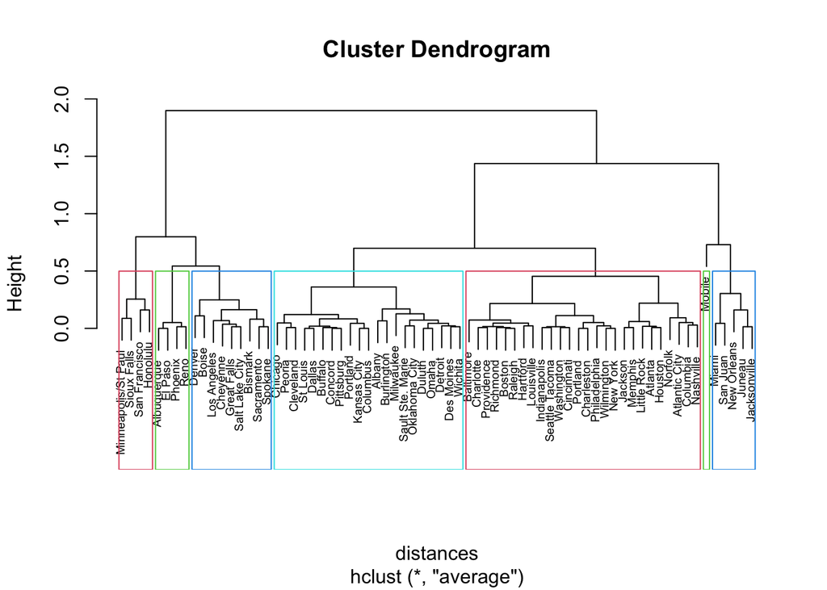

```r
plot(precip_scaled_dendo, cex = 0.6)
rect.hclust(precip_scaled_dendo, h = 0.5, border = 2:5)
```

In this dendrogram, you can see how the clusters are formed at height of .5, which shows us 7 different clusters. As we cluster at different heights, our clusters change. You can see this detailed below.

I also wanted to present a different format, one tracing clusters through color as they move up a the tree to the specific height. We do this through the color_branches() command from the dendextend package. You can see this shown below.

```r
library(dendextend)
```

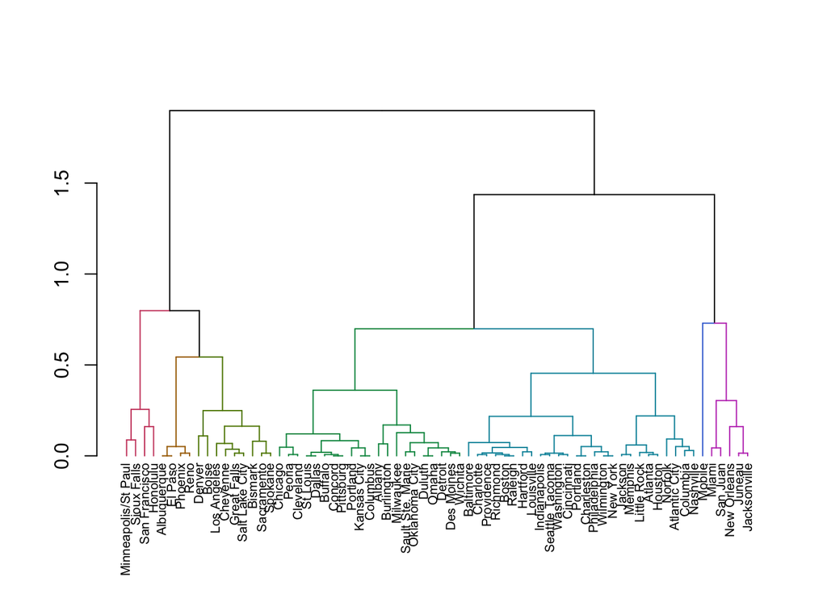

```r
precip_dendro_trace <- as.dendrogram(hclust(distances, method = "average", members = NULL))
precip_color_trace <- color_branches(precip_dendro_trace, h = .5)
precip_color_trace <- set(precip_color_trace, "labels_cex", 0.65)
plot(precip_color_trace)
```

```r
#https://cran.r-project.org/web/packages/dendextend/vignettes/FAQ.html
```

## Clustering at different heights

Now, we will analyze clustering at different heights. The height of a dendrogram shows disimilarity between clusters. *The taller the branch (more height), the larger difference in distances between clusters*. In our rect.hclust() command, we can choose the number of clusters based on the height of dissimilarity described above. Visually, I will represent these at each height levels of: 0.5, 1.0, 1.5, and 2.0. I have plotted the 0.5 above, and you can see the remaining noted in the next plots.

**Height of 0.5 [original dendrogram from above]**

```r
distances <- dist(precip_scaled, method = "euclidean", diag = FALSE, upper = TRUE)
precip_scaled_dendo <- hclust(distances, method = "average", members = NULL)
precip_scaled_dendo
```

```
##
## Call:
## hclust(d = distances, method = "average", members = NULL)
##
## Cluster method   : average
## Distance         : euclidean
## Number of objects: 70
```

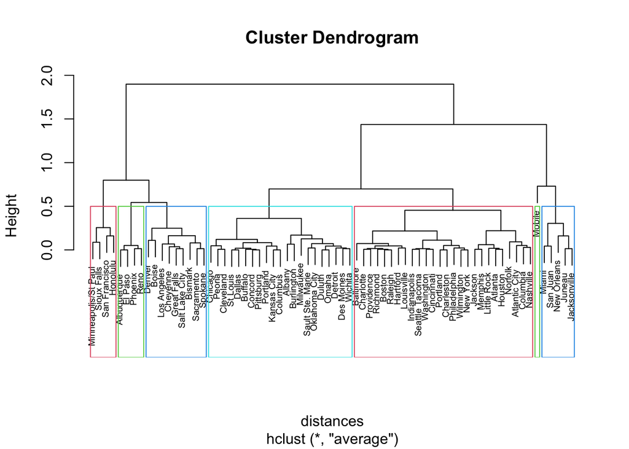

```r
plot(precip_scaled_dendo, cex = 0.6)
rect.hclust(precip_scaled_dendo, h = 0.5, border = 2:5)
```

**Height of 1**

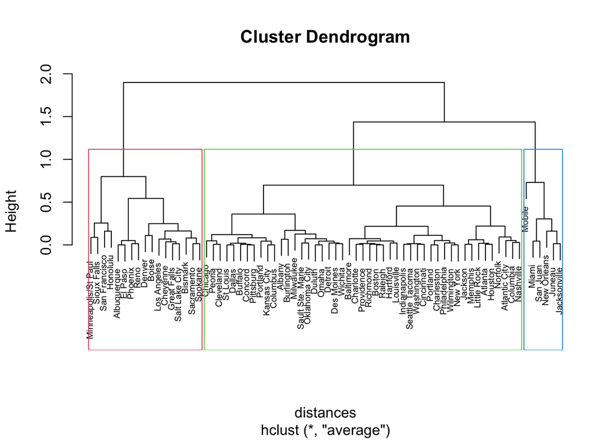

```r
plot(precip_scaled_dendo, cex = 0.6)
rect.hclust(precip_scaled_dendo, h = 1, border = 2:5)
```

**Heigt of 1.5**

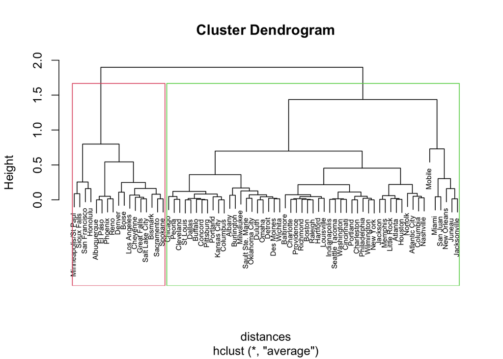

```r
plot(precip_scaled_dendo, cex = 0.6)
rect.hclust(precip_scaled_dendo, h = 1.5, border = 2:5)
```

**Height of 2**

[figure not shown]

```r
plot(precip_scaled_dendo, cex = 0.6)
rect.hclust(precip_scaled_dendo, h = 2, border = 2:5)
```

As we can see from all of these plots, the number of clusters changes depending on the height of the similarities. In this case, we will use the ‘h = 0.5’ example to demonstrate clustering at the lower level of disimilarity, and be able to move to our model by using the 7 different classes shown, and working through classification that way. I am choosing to do this because at h = 0.5, we can see the first real measures of disimilarities in the data, with the first measures of taller branches.

## Manually creating the clusters

Because agglomeritive heirarchical clustering is unsupervised, we need to create these clusters to measure the quality of the clustering. We will do this using the cutree() function, which will split our data into 7 clusters, based on where they are drawn in the dendrogram with h = 0.5.

```r
clusters <- cutree(precip_scaled_dendo, h = .5)
clusters #retrieved from https://uc-r.github.io/hc_clustering
```

```
##              Mobile              Juneau             Phoenix         Little Rock
##                   1                   2                   3                   4
##         Los Angeles          Sacramento       San Francisco              Denver
##                   5                   5                   6                   5
##            Hartford          Wilmington          Washington        Jacksonville
##                   4                   4                   4                   2
##               Miami             Atlanta            Honolulu               Boise
##                   2                   4                   6                   5
##             Chicago              Peoria        Indianapolis          Des Moines
##                   7                   7                   4                   7
##             Wichita          Louisville         New Orleans            Portland
##                   7                   4                   2                   4
##           Baltimore              Boston             Detroit    Sault Ste. Marie
##                   4                   4                   7                   7
##              Duluth Minneapolis/St Paul             Jackson         Kansas City
##                   7                   6                   4                   7
##            St Louis         Great Falls               Omaha                Reno
##                   7                   5                   7                   3
##             Concord       Atlantic City         Albuquerque              Albany
##                   7                   4                   3                   7
##             Buffalo            New York           Charlotte             Raleigh
##                   7                   4                   4                   4
##             Bismark          Cincinnati           Cleveland            Columbus
##                   5                   4                   7                   7
##       Oklahoma City            Portland        Philadelphia           Pittsburg
##                   7                   7                   4                   7
##          Providence            Columbia         Sioux Falls             Memphis
##                   4                   4                   6                   4
##           Nashville              Dallas             El Paso             Houston
##                   4                   7                   3                   4
##      Salt Lake City          Burlington             Norfolk            Richmond
##                   5                   7                   4                   4
##      Seattle Tacoma             Spokane          Charleston           Milwaukee
##                   4                   5                   4                   7
##            Cheyenne            San Juan
##                   5                   2
```

```r
table(clusters)
```

```
## clusters
##  1  2  3  4  5  6  7
##  1  5  4 26  9  4 21
```

This created our table of clusters, and showing the output for how many instances are in each cluster.

## Retrieving cluster data

```r
aggregate(precip, list(clusters), min)
```

```
##   Group.1    x
## 1       1 67.0
## 2       2 54.5
## 3       3  7.0
## 4       4 38.7
## 5       5 11.5
## 6       6 20.7
## 7       7 29.1
```

```r
aggregate(precip, list(clusters), max)
```

```
##   Group.1    x
## 1       1 67.0
## 2       2 59.8
## 3       3  7.8
## 4       4 49.2
## 5       5 17.4
## 6       6 25.9
## 7       7 37.6
```

```r
aggregate(precip, list(clusters), mean)
```

```
##   Group.1        x
## 1       1 67.00000
## 2       2 57.00000
## 3       3  7.45000
## 4       4 43.25385
## 5       5 14.90000
## 6       6 23.55000
## 7       7 33.68095
```

Above, you can see we have collected data from the individual clusters. I have written out this data below:

Cluster 1: min = 67in; max = 67in; mean = 67in Cluster 2: min = 54.5in; max = 59.8; mean = 57in Cluster 3: min = 7.0in; max = 7.8in; mean = 7.45in Cluster 4: min = 38.7in; max = 49.2in; mean = 43.25in Cluster 5: min = 11.5in; max = 17.4in; mean = 14.9in Cluster 6: min = 20.7in; max = 25.9in; mean = 23.55in Cluster 7: min = 29.1in; max = 37.6in; mean = 33.68in

This shows us how we can classify an unseen data point in a new cluster.

# Wait, but what if we predicted another city…?

As we can see, R chose the number of clusters based on the heights. So, what if we added another city? How would we cluster it based what we know about the distances/heights?

Our random city will be called *Rainbow Land*, and it has a precipitation value of 43.2 in. Well, we know that with a precipitation of 43.2, the instance would start in close quarters with Providence, who has a preciptation value of 42.8, meaning they are only .4in away from eachother. We can see the cluster data written above, which shows us that *Rainbow Land* would fall in cluster 4, as it is very close to the mean, and also within the range of preciptation for cluster 4.

## Creating our readable dataset… data wrangling…

Now, we want to add our cluster table to our precip data. But, we have an issue. Because our precip data is a vector with names previously loaded into it, it is not malleable like we need it to be. So, we need to create a dataset with everything named in order to create our model and add our clusters to each instance. This is all done in the code below.

```r
names <- c("Mobile", "Juneau", "Pheonix", "Little Rock",
           "Los Angeles", "Sacramento", "San Francisco", "Denver", "Hartford",
           "Wilmington", "Washington", "Jacksonville", "Miami", "Atlanta", "Honolulu",
           "Boise", "Chicago", "Peoria", "Indianapolis", "Des Moines", "Wichita",
           "Louisville", "New Orleans", "PortlandO", "Baltimore", "Boston", "Detroit",
           "Sault Ste. Marie", "Duluth", "Minneapolis/St Paul", "Jackson", "Kansas City", "St Louis",
           "Great Falls", "Omaha", "Reno", "Concord", "Atlantic City", "Albuquerque", "Albany",
           "Buffalo", "New York", "Charlotte", "Raleigh", "Bismark", "Cincinnati", "Cleveland",
           "Columbus", "Oklahoma City", "PortlandM", "Philadelphia", "Pittsburg", "Providence", "Columbia",
           "Sioux Falls", "Memphis", "Nashville", "Dallas", "El Paso", "Houston", "Salt Lake City", "Burlington", "Norfolk", "Richmond",
           "Seattle Tacoma", "Spokane", "Charleston", "Milwaukee", "Cheyenne", "San Juan")

precipitation <- c(67.0, 54.7, 7.0, 48.5, 14.0, 17.2, 20.7, 13.0, 43.4, 40.2, 38.9, 54.5, 59.8, 48.3, 22.9, 11.5, 34.4, 35.1, 38.7,
                   30.8, 30.6, 43.1, 56.8, 40.8, 41.8, 42.5, 31.0, 31.7, 30.2, 25.9, 49.2, 37.0, 35.9, 15.0, 30.2, 7.2, 36.2, 45.5, 7.8, 33.4,
                   36.1, 40.2, 42.7, 42.5, 16.2, 39.0, 35.0, 37.0, 31.4, 37.6, 39.9, 36.2, 42.8, 46.4, 24.7, 49.1, 46.0, 35.9, 7.8, 48.2, 15.2, 32.5,
                   44.7, 42.6, 38.8, 17.4, 40.8, 29.1, 14.6, 59.2)

precip.NEW <- data.frame(names, precipitation)
precip.NEW = precip.NEW %>%
  mutate(cluster_number = case_when(names == "Minneapolis/St Paul" ~ 6,
                                   names ==  "Sioux Falls" ~ 6,
                                   names == "San Francisco" ~ 6,
                                   names == "Honolulu" ~ 6,
                                   names == "Albuquerque" ~ 3,
                                   names == "El Paso" ~ 3,
                                   names == "Pheonix" ~ 3,
                                   names == "Reno" ~ 3,
                                   names == "Denver" ~ 5,
                                   names == "Boise" ~ 5,
                                   names == "Los Angeles" ~ 5,
                                   names == "Cheyenne" ~ 5,
                                   names == "Great Falls" ~ 5,
                                   names == "Salt Lake City" ~ 5,
                                   names == "Bismark" ~ 5,
                                   names == "Sacramento" ~ 5,
                                   names == "Spokane" ~ 5,
                                   names == "Chicago" ~ 7,
                                   names == "Peoria" ~ 7,
                                   names == "Cleveland" ~ 7,
                                   names == "St Louis" ~ 7,
                                   names == "Dallas" ~ 7,
                                   names == "Buffalo" ~ 7,
                                   names == "Concord" ~ 7,
                                   names == "Pittsburg" ~ 7,
                                   names == "PortlandO" ~ 4,
                                   names == "Kansas City" ~ 7,
                                   names == "Columbus" ~ 7,
                                   names == "Albany" ~ 7,
                                   names == "Burlington" ~ 7,
                                   names == "Milwaukee" ~ 7,
                                   names == "Sault Ste. Marie" ~ 7,
                                   names == "Oklahoma City" ~ 7,
                                   names == "Duluth" ~ 7,
                                   names == "Omaha" ~ 7,
                                   names == "Detroit" ~ 7,
                                   names == "Des Moines" ~ 7,
                                   names == "Wichita" ~ 7,
                                   names == "Baltimore" ~ 4,
                                   names == "Charlotte" ~ 5,
                                   names == "Providence" ~ 4,
                                   names == "Richmond" ~ 4,
                                   names == "Boston" ~ 4,
                                   names == "Raleigh" ~ 4,
                                   names == "Hartford" ~ 4,
                                   names == "Louisville" ~ 4,
                                   names == "Indianapolis" ~ 4,
                                   names == "Seattle Tacoma" ~ 4,
                                   names == "Washington" ~ 4,
                                   names == "Cincinnati" ~ 4,
                                   names == "PortlandM" ~ 7,
                                   names == "Charleston" ~4,
                                   names == "Philadelphia" ~ 4,
                                   names == "Wilmington" ~ 4,
                                   names == "New York" ~ 4,
                                   names == "Jackson" ~ 4,
                                   names == "Memphis" ~ 4,
                                   names == "Little Rock" ~ 4,
                                   names == "Atlanta" ~ 4,
                                   names == "Houston" ~ 4,
                                   names == "Norfolk" ~ 4,
                                   names == "Atlantic City" ~ 4,
                                   names == "Columbia" ~ 4,
                                   names == "Nashville" ~ 4,
                                   names == "Mobile" ~ 1,
                                   names == "Miami" ~ 2,
                                   names == "San Juan" ~ 2,
                                   names == "New Orleans" ~ 2,
                                   names == "Juneau" ~ 2,
                                   names == "Jacksonville" ~ 2)) %>%
  mutate(city_weather_type = case_when(cluster_number == 1 ~ "Hot and Very Wet",
                               cluster_number == 2 ~ "Wet",
                               cluster_number == 3 ~ "Hot and Dry",
                               cluster_number == 4 ~ "Cold and Wet",
                               cluster_number == 5 ~ "Cold and Dry",
                               cluster_number == 6 ~ "Hot and Humid",
                               cluster_number == 7 ~ "Temperate Dry"))
```

You can view the output of this new dataset in our precip.NEW.csv file attached to this report submission.

## Model evaluation (using a human)

Because this is unsupervised clustering, and we do not have a ‘right’ answer for our clusters in relation to precipitation, we do not have a computer algorithm that will display an accurate evaluation for us. So, because the purpose of heirarchical clustering is to cluster based on a numerical value, we will ask a human to cluster (classify) 7 cities into what they think is the correct bin (class) based on their numerical values.

The data shown below titled ‘human_prediction’ is the random sample of 7 cities chosen from our dataset. I used the code ‘sample_n(7, replace = FALSE)’ to do this, but if I submitted that code, it would take a random sample each time the code was ran, so I wrote out the 7 that were chosen.

```r
human_prediction = precip.NEW %>%
  filter(names %in% c("Salt Lake City", "Pittsburg", "Providence", "Bismark", "Houston", "Charlotte", "Spokane")) %>%
  mutate(human_predicted_weather_type = case_when(names == "Salt Lake City" ~ "Hot and Dry",
                                                  names == "Pittsburg" ~ "Cold and Wet",
                                                  names == "Providence" ~ "Cold and Wet",
                                                  names == "Bismark" ~ "Cold and Dry",
                                                  names == "Houston" ~ "Hot and Dry",
                                                  names == "Charlotte" ~ "Hot and Humid",
                                                  names == "Spokane" ~ "Cold and Wet"))
human_prediction
```

```
##            names precipitation cluster_number city_weather_type
## 1      Charlotte          42.7              5      Cold and Dry
## 2        Bismark          16.2              5      Cold and Dry
## 3      Pittsburg          36.2              7     Temperate Dry
## 4     Providence          42.8              4      Cold and Wet
## 5        Houston          48.2              4      Cold and Wet
## 6 Salt Lake City          15.2              5      Cold and Dry
## 7        Spokane          17.4              5      Cold and Dry
##   human_predicted_weather_type
## 1                Hot and Humid
## 2                 Cold and Dry
## 3                 Cold and Wet
## 4                 Cold and Wet
## 5                  Hot and Dry
## 6                  Hot and Dry
## 7                 Cold and Wet
```

```r
prop_correct = 2/7
p_incorrect = 1-prop_correct
p_incorrect
```

```
## [1] 0.7142857
```

When evaluating the human prediction, as this table output demonstrates, the human predictor was indicitive of this model not being the best. I calcualted the probability of correct by stating on the numerator how many cities the human classified just like the computer did, and the denominator was the test sample size, which is 7. I calculated the p_incorrect, as seen above, and our p_incorrect for predicting this testing set of 7 values was 71.4%. This is a huge probability of incorrect classification, further demonstrating that this model was not the best.

## What other model can we use?

Well, after I saw that this model of agglomeritive heirarchical clustering was not the most predictive, I chose to preform a decision tree on the data, too, to see how this classification would classify our unknown data point of *Rainbow Land* with a precipitation of 43.2in.

```r
library(ISLR)
library(rpart)
precip_decision_tree <- rpart(as.factor(cluster_number) ~ precipitation, data= precip.NEW, method= "class")
summary(precip_decision_tree)
```

```
## Call:
## rpart(formula = as.factor(cluster_number) ~ precipitation, data = precip.NEW,
##     method = "class")
##   n= 70
##
##           CP nsplit rel error    xerror       xstd
## 1 0.46666667      0 1.0000000 1.0000000 0.08908708
## 2 0.20000000      1 0.5333333 0.5333333 0.08825168
## 3 0.08888889      2 0.3333333 0.3333333 0.07628962
## 4 0.01000000      3 0.2444444 0.2888889 0.07230154
##
## Variable importance
## precipitation
##           100
##
## Node number 1: 70 observations,    complexity param=0.4666667
##   predicted class=4  expected loss=0.6428571  P(node) =1
##     class counts:     1     5     4    25    10     4    21
##    probabilities: 0.014 0.071 0.057 0.357 0.143 0.057 0.300
##   left son=2 (32 obs) right son=3 (38 obs)
##   Primary splits:
##       precipitation < 38.15 to the right, improve=17.46823, (0 missing)
##
## Node number 2: 32 observations,    complexity param=0.08888889
##   predicted class=4  expected loss=0.21875  P(node) =0.4571429
##     class counts:     1     5     0    25     1     0     0
##    probabilities: 0.031 0.156 0.000 0.781 0.031 0.000 0.000
##   left son=4 (7 obs) right son=5 (25 obs)
##   Primary splits:
##       precipitation < 49.15 to the right, improve=6.562143, (0 missing)
##
## Node number 3: 38 observations,    complexity param=0.2
##   predicted class=7  expected loss=0.4473684  P(node) =0.5428571
##     class counts:     0     0     4     0     9     4    21
##    probabilities: 0.000 0.000 0.105 0.000 0.237 0.105 0.553
##   left son=6 (17 obs) right son=7 (21 obs)
##   Primary splits:
##       precipitation < 27.5  to the left,  improve=13.06811, (0 missing)
##
## Node number 4: 7 observations
##   predicted class=2  expected loss=0.2857143  P(node) =0.1
##     class counts:     1     5     0     1     0     0     0
##    probabilities: 0.143 0.714 0.000 0.143 0.000 0.000 0.000
##
## Node number 5: 25 observations
##   predicted class=4  expected loss=0.04  P(node) =0.3571429
##     class counts:     0     0     0    24     1     0     0
##    probabilities: 0.000 0.000 0.000 0.960 0.040 0.000 0.000
##
## Node number 6: 17 observations
##   predicted class=5  expected loss=0.4705882  P(node) =0.2428571
##     class counts:     0     0     4     0     9     4     0
##    probabilities: 0.000 0.000 0.235 0.000 0.529 0.235 0.000
##
## Node number 7: 21 observations
##   predicted class=7  expected loss=0  P(node) =0.3
##     class counts:     0     0     0     0     0     0    21
##    probabilities: 0.000 0.000 0.000 0.000 0.000 0.000 1.000
```

```r
printcp(precip_decision_tree)
```

```
##
## Classification tree:
## rpart(formula = as.factor(cluster_number) ~ precipitation, data = precip.NEW,
##     method = "class")
##
## Variables actually used in tree construction:
## [1] precipitation
##
## Root node error: 45/70 = 0.64286
##
## n= 70
##
##         CP nsplit rel error  xerror     xstd
## 1 0.466667      0   1.00000 1.00000 0.089087
## 2 0.200000      1   0.53333 0.53333 0.088252
## 3 0.088889      2   0.33333 0.33333 0.076290
## 4 0.010000      3   0.24444 0.28889 0.072302
```

Here, we can see the numerical representations of our decision tree, which show that the root node error for the decision tree is 64.2%. This is not a great error statistic, but we do see our CP value decreasing with each split, showing the tree increasingly gaining predictability as it goes through splits.

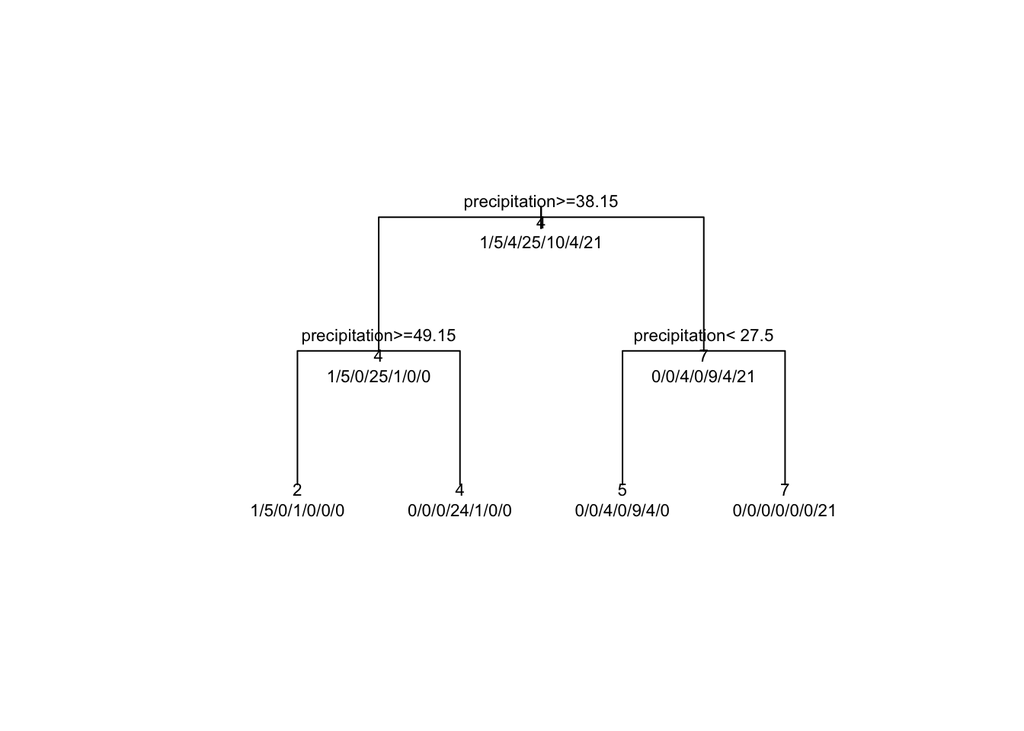

```r
plot(precip_decision_tree, uniform=TRUE, margin = 0.3)
text(precip_decision_tree, use.n=TRUE, all=TRUE, cex=0.7)
```

```r
#http://www.sthda.com/english/wiki/add-titles-to-a-plot-in-r-software
```

As we can see on the tree, the data splits first at precipitation >= 38.15in, where we can see the counts for each cluster (ex. 1/5/4/25/10/4/21). On the true side of that split, we have another split at precipitation >= 49.15. This then splits those counts into either true (1/5/0/1/0/0/0) or false (0/0/0/24/1/0/0). On the false side, we have the next split at precipitation < 27.5in. For true, we have (0/0/4/0/9/4/0). For false, we have (0/0/0/0/0/0/21).

As for our city *Rainbow Land*, we can see it go through the tree! First, it would split to the left (true), because 43.2in>=38.15in. Then, it gets split from that node, to the right leaf, leaving *Rainbow Land* to be classified as class 4.

## Evaluating the Decision Tree

Here, we will evaluate our decision tree.

```r
train_control <- trainControl(method = "LOOCV")

modelA1 <- train(as.factor(cluster_number) ~ precipitation, data = precip.NEW,
                 method = "rpart",
                 trControl = train_control)

print(modelA1)
```

```
## CART
##
## 70 samples
##  1 predictor
##  7 classes: '1', '2', '3', '4', '5', '6', '7'
##
## No pre-processing
## Resampling: Leave-One-Out Cross-Validation
## Summary of sample sizes: 69, 69, 69, 69, 69, 69, ...
## Resampling results across tuning parameters:
##
##   cp          Accuracy   Kappa
##   0.08888889  0.7857143  0.69905417
##   0.20000000  0.6571429  0.50442478
##   0.46666667  0.3571429  0.02113114
##
## Accuracy was used to select the optimal model using the largest value.
## The final value used for the model was cp = 0.08888889.
```

We can see here that we used Leave-One-Out cross validation as our resampling method, and we can see in the code that we used rpart as our evaluation method in our model. This illustrated for us that our accuracy for the decision tree was about 78.57%, which is much higher than our agglomeritive heirarchical clustering model. This is because our original model was unsupervised, and we were predicting a classification that does not truely exist in our data. With our decision tree, although our data was still unsupervised, our clusters were already drawn out from our previous model, so our LOOCV showed us that our data actually has somethign to predict. In this case, our accuracy was quite high.

In conclusion, our heirarchical clustering model was not the greatest. Our decision tree model was much more efficient, and painted a better picture of our classification. Our human evaluation metric for our heirarchical clustering model showed us that our human predictor was much stronger, showing us the probabilty of error of our clustering model. Overall, our decision tree model was much better.